# Fisher Information Matrix

ryamada

2017年2月25日

# 1 尤度関数は$x$で変わる Likelihood function varies with $x$

尤度関数 Likelihood function
$$L(\mu,\sigma^2|X) = \prod_{i=1}^n f(x_i|\mu,\sigma^2),$$

ただし、where,
$$f(u|\mu,\sigma^2) = \frac{1}{\sqrt{2\pi \sigma^2}} e^{-\frac{(u-\mu)^2}{2\sigma^2}} .$$

対数尤度関数は The log-likelihood function is;
$$l(\mu,\sigma^2|X) = \log{L(\mu,\sigma^2|X)} = \sum_{i=1}^n \log{f(x_i|\mu,\sigma^2)}\\
= -\frac{n}{2} \log{2\pi} - n\log{\sigma} - \frac{1}{2\sigma^2} \sum_{i=1}^n(x_i-\mu)^2 .$$

## 1.1 Exercise 1

### 1.1.1 Exercise 1-1

$X_1={3,4,6}$,$X_2={2,4,7}$のときの$l(\mu,\sigma^2|X_1),l(\mu,\sigma^2|X_2)$, を$\mu\in [2,7]$,$\sigma \in [1,2]$ について併せて3次元プロットで描け。

Draw a $l(\mu,\sigma^2|X_1),l(\mu,\sigma^2|X_2)$’s surface, where $X_1={3,4,6}$,$X_2={2,4,7}$ in 3D for $\mu\in [2,7]$,$\sigma \in (1,2)$ in the same panel.

# 2 対数尤度関数の期待値、エントロピー Expected value of log-likelihood function and entropy

正規分布 $N(\mu,\sigma^2)$ があって、そこからサンプル$X =\{x_i\} \in \mathbf{R}^n$が取られることを考える。

Assume a normal distribution $N(\mu,\sigma^2)$ and take a sample set $X =\{x_i\} \in \mathbf{R}^n$.

ある特定の$(\mu,\sigma^2)$を想定しているとき、ある特定の$X =\{x_i\} \in \mathbf{R}^n$が観察される確率密度は

$$L_p(X|\mu,\sigma^2) = \prod_{i=1}^n f(x_i|\mu,\sigma^2)$$

色々な$X$が観測されうるが、取りうる$X$について積分すると、1。

$$\int_X L_p(X|\mu,\sigma^2) dX = 1$$

特定の$(\mu,\sigma^2)$であるときに、観察$X$をして、その対数尤度を調べるとする。

対数尤度は$X$によって変わるが、その期待値は

$$E(l(\mu,\sigma^2)) = \int_X L_p(X|\mu,\sigma^2)l(\mu,\sigma^2|X) dX\\
=\int_X p(x) \log{p(x)} dX$$

エントロピー(平均情報量)の定義 $H(X) = -\int p(x)\log{p(x)}dx$ の符号を入れ替えたもののことである。

## 2.1 Exercise 2

### 2.1.1 Exercise 2-1

$\mu\in [2,7]$,$\sigma \in [1,2]$ について、対数尤度関数の期待値(エントロピーx(-1))を3Dプロットで示せ。 ただし、$(\mu,\sigma)$のペアごとに、正規乱数を発生し、その対数の和をとると、尤度関数の期待値の近似値となることを理解し、その結果を用いて描図せよ。

The expected value of log-likelihood function is estimated as the sum of log-likelihood of random values that are generated from the corresponding normal distribution. Estimate the expected value of log-likelihood function in that way for $\mu\in [2,7]$,$\sigma \in [1,2]$ and draw them in 3D plot.

# 3 対数尤度関数の微分、最尤推定、スコア関数 Derivative of log-likelihood function , maximum likelihood estimate and score function

対数尤度関数の期待値を扱った。今度は対数尤度関数をパラメタで偏微分したものの期待値を扱う。

対数尤度関数の微分は、最尤推定値$\hat{\theta_i}$において 0になることに利用できる。

The expected value of log-likelihood function was discussed. Now the partial derivative of log-likelihood function is to be handled.

The maximum likelihood estimate $\hat{\theta_i}$, makes it 0.

$$\frac{\partial } {\partial \theta_i} l(\hat{\theta_i}) = 0$$

この$\frac{\partial } {\partial \theta_i} l(\theta_i|X)$ という関数について考える。

今、$\theta_i$の値はわからないながら、観察をしたとする。 観察には誤差があるので、必ずしも$\frac{\partial } {\partial \theta_i} l(\hat{\theta_i}|X)$の値は0とは限らない。

もし観察を繰り返したとすると、その平均値はいくつか、といえば、それは、期待値となって

When repeating the sampling procedures, the values of function $\frac{\partial } {\partial \theta_i} l(\theta_i|X)$ is not always 0 because observations vary with random error.

The sample average of the values of the function from repeated observations is the approximation of the expected value.

$$E(\frac{\partial}{\partial \theta_i}l(\theta)) = \int_X L_p(X|\theta)\frac{\partial}{\partial \theta_i}l(\theta|X) dX$$

Assume that you take one sample from the normal distribution with $\mu=3,\sigma=2$. Show the partial derivatives of log-likelihood function.

### 3.0.1 Exercise 3-2

正規乱数を１つ観察することを多数回繰り返したとして、パラメタの偏微分の平均値がいくつになるか、シミュレーションし、その平均値、最大値、最小値を示し、ヒストグラムを示せ。

Repeat the sampling many times and calculate the derivative function values. Answer its mean, max andmin and show their histograms.

```
## [1] -6.680516e-05  1.766469e-03
```

```
## [1] -2.029984  2.276398
```

```
## [1] -0.500000  9.863977
```

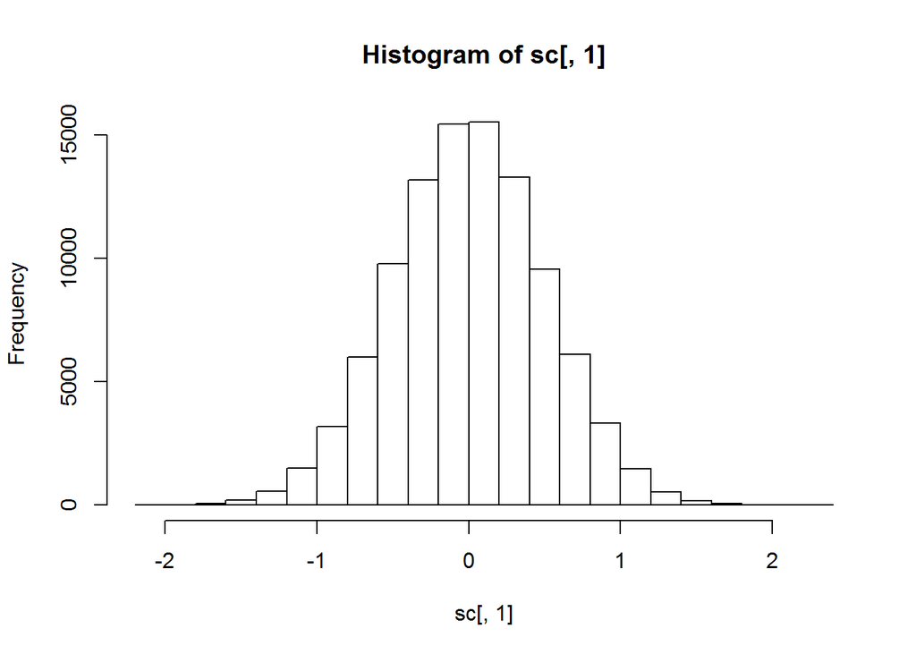

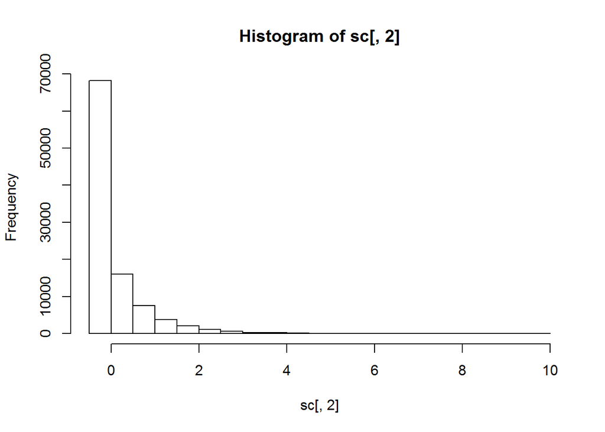

この対数尤度関数を(偏)微分した関数をスコア関数と言う。

The (partial) derivatives of log-likelihood function is called score function.

スコア関数の値が0からどれくらい離れているかをp値に結び付けた検定手法がスコア検定。

Score test is a statistical test that measures the value of score function and converts the value or the deviation from 0 to p-value.

# 4 スコア関数の分散、フィッシャー情報量 Variance of Score function, Fisher Information

スコア関数 $\frac{\partial}{\partial \theta_i} l(\theta)$ の期待値$E(\frac{\partial}{\partial \theta_i} l(\theta)) = \int_X L_p(X|\theta)\frac{\partial}{\partial \theta_i} l(\theta) dX$は0なので、

スコア関数の値のばらつき(分散)は、単純に

Variance of values of score functions is the expected value of its square because its mean is 0.
$$E(\frac{\partial}{\partial \theta_i} l(\theta) \times \frac{\partial}{\partial \theta_i} l(\theta)) = \int_X L_p(X|\theta)(\frac{\partial}{\partial \theta_i} l(\theta)\times \frac{\partial}{\partial \theta_i} l(\theta)) dX$$

異なるパラメタ$\theta_i,\theta_j$の組み合わせについても考えれば、

Covariance among the derivatives of different parameters are also considered,

$$E(\frac{\partial}{\partial \theta_i} l(\theta) \times \frac{\partial}{\partial \theta_j} l(\theta)) = \int_X L_p(X|\theta)(\frac{\partial}{\partial \theta_i} l(\theta)\times \frac{\partial}{\partial \theta_j} l(\theta)) dX$$
も併せて、正方行列が作れる。これをフィッシャー情報量と言う。

These make a square matrix, called Fisher information;
$$E(\frac{\partial}{\partial \theta_i}l \frac{\partial}{\partial \theta_j}l ) = \begin{pmatrix}\frac{\partial}{\partial \theta_1}l \frac{\partial}{\partial \theta_1}l ,& \frac{\partial}{\partial \theta_1}l \frac{\partial}{\partial \theta_2}l,&...,&\frac{\partial}{\partial \theta_1}l \frac{\partial}{\partial \theta_n}l\\ \frac{\partial}{\partial \theta_2}l \frac{\partial}{\partial \theta_1}l,&...,&...,&\frac{\partial}{\partial \theta_2}l \frac{\partial}{\partial \theta_n}l\\
...,&...,&...,&...\\
\frac{\partial}{\partial \theta_n}l \frac{\partial}{\partial \theta_1}l,&\frac{\partial}{\partial \theta_n}l \frac{\partial}{\partial \theta_2}l,&....,&\frac{\partial}{\partial \theta_n}l \frac{\partial}{\partial \theta_n}l) \end{pmatrix}$$

フィッシャー情報量が大きいときは、スコア関数の値は0を中心にばらつきが大きくなり、フィッシャー情報量が小さいときは、スコア関数の値は0を中心にばらつきが小さくなることを示す。

Regardless of Fisher information, score function takes values around 0. When Fisher information is large, score varies more and when Fisher information is small, it varies less.

## 4.1 Exercise 4

### 4.1.1 Exercise 4-1

スコア関数の期待値が0であることを以下の複数の式にて確認せよ。

$$E(\frac{\partial}{\partial \theta_i} l(\theta)) = \int_X L_p(X|\theta)\frac{\partial}{\partial \theta_i} l(\theta) dX$$

$$\log{L_p(X|\theta)} = l(\theta|X)$$
$$\frac{\partial}{\partial \theta_i} l(\theta) = \frac{\partial}{\partial \theta_i} \log{L_p(X|\theta)}\\
=\frac{1}{L_p(X|\theta)}\frac{\partial L_p(X|\theta)}{\partial \theta_i}$$
$$L_p(X|\theta)\frac{\partial}{\partial \theta_i} l(\theta) = L_p(X|\theta)\frac{1}{L_p(X|\theta)}\frac{\partial L_p(X|\theta)}{\partial \theta_i} \\
=\frac{\partial L_p(X|\theta)}{\partial \theta_i}$$
$$E(\frac{\partial}{\partial \theta_i} l(\theta)) = \int_X L_p(X|\theta)\frac{\partial}{\partial \theta_i} l(\theta) dX\\
=\int_X \frac{\partial L_p(X|\theta)}{\partial \theta_i} dX\\
=\frac{\partial}{\partial \theta_i}\int_X L_p(X|\theta) dX\\
=\frac{\partial}{\partial \theta_i} \cdot 1\\
=0$$